# HW2

Susanna Bravi, Camilla Brigandì, Lorenzo Pannacci

2023-12-27

```r
# Libraries -------------------------------
library(ggplot2)
library(plotly)
library(extraDistr) #needed for the rademacher distr

# Seed for reproducibility ----------------------------
set.seed(26111998)
```

# Exercise 1:

## Population selected

```r
# Population -------------------
n = 1000000
# basic population we want to try...N(0,1)
pop = rnorm(n)
# second population we want to try... RADEMACHER DISTR
pop_rad = rsign(n)
```

The first thing to do to solve the exercise is find two subgaussian distributions, from which we’ll extract two different populations.

The first one we choose is the **Standard Gaussian**, that satisfies the subgaussianity requirement (since they are defined as distributions whose tails decay at least as fast as those of a Gaussian) and it’s also a “comfortable” distribution to work with for us since we are familiar with it.

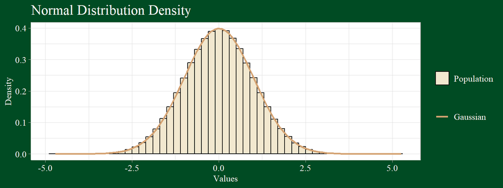

The second distribution we chose is the **Rademaker distribution**, which is the distribution of a step in the symmetric random walk: it takes values 1 and -1 with equal probability:

$$\begin{equation*}
f(k)=\left\{\begin{matrix}
\frac{1}{2} & if & k = -1 \\
\frac{1}{2} & if & k = +1 \\
0 & otherwise
\end{matrix}\right.
\end{equation*}$$

This distribution is subgaussian:

- For $t$ in $[-\infty, 1]$:
  $$\begin{equation*}
  1 = \mathbb{P}(|X| ≥ t) ≤ 2 \exp(0) ≤ 2 \exp(t^2)
  \end{equation*}$$
  Since the exponential is an increasing function and it takes value 1 at 0;
- For $t$ in $[1, + \infty)$:
  $$\begin{equation*}
  0 = \mathbb{P}(|X| ≥ t) ≤ \exp(t^2)
  \end{equation*}$$
  Since the exponential takes only positive values.

Now that we have the distributions, we extract a sample of $1.000.000$ units from each of them to simulate the two populations we are working with.

## Systematic sampling

In order to both keep the sequentiality of the data from the population and to simulate different time flows we sample the data using systematic sampling in the following way:

- we extract the index $i_{\text{start}}$ of the first sampling unit uniformly at random;
- we define the “step” of the sampling process as follows by taking the floor of $\frac{n - i_{\text{start}}}{t_{\text{max}}}$, if this is bigger than 1, and 1 elseway. Note that in the previous equation $n$ is the population size and $t_{\text{max}}$ is the maximum sample size we want to examine, as stated in the homework text;
- we collect the first ${t_{\text{min}}}$ indices spaced by “step” starting from $i_{\text{start}}$, where ${t_{\text{min}}}$ is the minimum sample size we want to take into consideration (in this case is set at $10$);
- we extract the starting sample by getting the population vector items whose indices are the ones we collected.

```r
start_sample_systematic <- function(population, tmin, tmax){
  if(tmax < length(population)){
    start_idx = sample(1:length(population), size = 1)

    if (start_idx + tmax > length(population)){
      return( start_sample_systematic(population, tmin, tmax) )
    }

    #fix the step for the systematic sampling
    step = floor( ((length(population) - start_idx) /tmax) )*( ((length(population) - start_idx)/tmax) >= 1 ) + 1* ( ((length(population) - start_idx)/tmax) < 1 )
    final_idx = start_idx + step*(tmin - 1)
    idx_vector_start = seq(start_idx, final_idx, step)
  }
  return(c(population[idx_vector_start], final_idx, step))
}
```

Since in the function we defined we return also the step of the sampling process, we can update the starting sample in order to increase its size by adding one sampling unit at a time following the same sampling rule. This is what we do inside the loop that defines one iteration of the simulation.

## Confidence Sequences and Confidence intervals computation

One of the important things left is the computation of the confidence intervals and sequences requested for the analysis. To be able to do so, we defined some functions that calculate them following their definitions:

```r
# Confidence sequence for sample of size t
C_Sequence <- function(smpl, t, alpha){
  smpl_m = sum(smpl)/t
  term <- 1.7 * sqrt((log(log(2*t))+0.72*log(10.4/alpha))/t)
  CS = c(smpl_m-term,smpl_m+term)
  return(CS)
}

# "Relaxed" confidence sequence for sample of size t
C_Sequence_relaxed <- function(smpl, t, alpha){
  sigma_hat <- var(smpl)
  smpl_m = sum(smpl)/t
  term <- sigma_hat * 1.7 * sqrt((log(log(2*t))+0.72*log(10.4/alpha))/t)
  CS = c(smpl_m-term,smpl_m+term)
  return(CS)
}

#Hoeffding CI
CI_Hoeff <- function(sequence, alpha, a, b){
  n <- length(sequence)
  t_alpha = sqrt( ((b-a)^2/(2*n)) * log(2/alpha) )
  sample_mean = mean(sequence)
  return(c(sample_mean-t_alpha, sample_mean + t_alpha))
}

# Chebyshev CI
CI_Cheb <- function(sequence, alpha, sigma){
  n <- length(sequence)
  t_alpha = sigma / sqrt(n*alpha)
  sample_mean = mean(sequence)
  return(c(sample_mean-t_alpha, sample_mean + t_alpha))
}

# Gaussian CI
CI_Gauss <- function(sequence, alpha){
  n <- length(sequence)
  z_alpha2 = qnorm(1-alpha/2)
  std_err = sd(sequence)
  sample_mean = mean(sequence)
  return(c(sample_mean - z_alpha2*(std_err/sqrt(n)), sample_mean + z_alpha2*(std_err/sqrt(n)) ))
}
```

## Metrics

In order to compare the performances of the confidence sequences and confidence intervals, we need to define some relevant metrics. We decided to use the ones suggested in the homework text: the *Average running length* and the *Cumulative Miscoverage Probability* that, when running the simulation, are summarized w.r.t. the sample size. To be able to calculate them, when running the simulation we saved some information needed for their computation:

- **CMP** - for each interval (both the ones in the sequences and the “singular” ones) we keep track of the presence in the interval of the “true mean” of the distributions from which the populations are extracted: we save a $1$ if the true mean is inside the interval and a $0$ if it isn’t;
- **ARL** - we compute the length of each interval and save it.

Then, those values are summarized:

- By calculating, for each sample size $t$ in $\{ t_{\text{min}}, \, t_{\text{min}} + 1, \dots, \, t_{\text{max}} \}$ the CMP as $\frac{M - \sum_{ I \in I_t } \mathbb{1}_{\{ \mu \in I \}} ( \text{I})}{M}$, where $M$ is the simulation size, and $I_t$ is the set of confidence intervals of a given type calculated on samples of sample size $t$.
- By taking the mean of the lengths of intervals of each of the examined sample sizes to get the ARL.

## Results and Analysis

To get the results, we did a simulation of size $1.000$ and saved the results in one row of a dataframe for each sample extracted. In each iteration of the simulation we let the sample size vary between $t_{\text{min}} = 10$ and $t_{\text{max}} = 5.000$.

```r
# Parameters ------------------------------
M <-  1000
alpha <- 0.05
tmin = 10
tmax = 5000
```

```r
# GAUSSIAN POPULATION

# initialize vector of sample sizes
t_vec = seq(tmin, tmax)
# Initialize true mean and variance of the population - needed for coverage measure
true_mean = 0 # change as needed
sigma = 1 #change - it's the population TRUE standard deviation

# Initialize data frame to save CS bounds (and associated sample sizes)
bounds = data.frame()

for(it in seq(1, M)){ # M is the simulation size, fixed somewhere above
  # extract starting sequence for the confidence sequence - FORSE NON DOVEVO FARE UNA FUNZIONE
  start_output = start_sample_systematic(pop, tmin, tmax)
  sequence = start_output[1:tmin] # initial sample
  final_idx = start_output[length(start_output) - 1 ] # index of the last element in the sample
  step = start_output[length(start_output)] # step of the systematic sampling

  # Initialize empty dataframe for the data of the iteration
  df_prov = data.frame()
  for(t in t_vec){
    # Calculate CI of the CS with sample size t
    CS <- C_Sequence(sequence, t, alpha)
    # Calculate CI of the relaxed CS with sample size t
    CS_relaxed <- C_Sequence_relaxed(sequence, t, alpha)
    #CI with Chebyshev
    CI_C <- CI_Cheb(sequence, alpha, sigma)
    #Gaussian CI
    CI_G <- CI_Gauss(sequence, alpha)

    ##### Info for the coverage metric
    TrueMeanIn_CS = (CS[1]<=true_mean) * (true_mean <= CS[2])
    TrueMeanIn_CSrelaxed = (CS_relaxed[1]<=true_mean) * (true_mean <= CS_relaxed[2])
    TrueMeanIn_Cheb = (CI_C[1]<=true_mean) * (true_mean <= CI_C[2])
    TrueMeanIn_Gauss = (CI_G[1]<=true_mean) * (true_mean <= CI_G[2])

    #### Length of the current intervals
    len_CS = abs(CS[1] - CS[2])
    len_CS_relaxed = abs(CS_relaxed[1] - CS_relaxed[2])
    len_Cheb = abs(CI_C[1] - CI_C[2])
    len_Gauss = abs(CI_G[1] - CI_G[2])

    # Save bounds and infos in the dataframe
    df_prov = rbind(df_prov, data.frame(sample_size = t,
                                        CS_lower = CS[1], CS_upper = CS[2], TrueMeanIn_CS = TrueMeanIn_CS, length_CS = len_CS,
                                        CS_relaxed_lower = CS_relaxed[1], CS_relaxed_upper = CS_relaxed[2], TrueMeanIn_CSrelaxed = TrueMeanIn_CSrelaxed, length_CSrelaxed = len_CS_relaxed,
                                        Chebyshev_lower = CI_C[1], Chebyshev_upper = CI_C[2], TrueMeanIn_Cheb = TrueMeanIn_Cheb, len_Chebyshev = len_Cheb,
                                        Gaussian_lower = CI_G[1], Gaussian_upper = CI_G[2], TrueMeanIn_Gauss = TrueMeanIn_Gauss, len_Gaussian = len_Gauss
    ))


    # Update sample - in the end we will have one element more than needed in the sample
    sequence <- append(sequence, pop[final_idx + step])

    # Update final_idx
    final_idx <- final_idx + step
  }

  bounds <- rbind(bounds, df_prov)
}

# This is for the RADEMACHER
bounds_rad = data.frame()

for(it in seq(1, M)){ # M is the simulation size
  print(it)
  # extract starting sequence for the confidence sequence
  start_output = start_sample_systematic(pop_rad, tmin, tmax)
  sequence = start_output[1:tmin] # initial sample
  final_idx = start_output[length(start_output) - 1 ] # index of the last element in the sample
  step = start_output[length(start_output)] # step of the systematic sampling

  # Initialize empty dataframe for this iteration
  df_prov = data.frame()
  for(t in t_vec){
    # Calculate CI of the CS with sample size t
    CS <- C_Sequence(sequence, t, alpha)
    # Calculate CI of the relaxed CS with sample size t
    CS_relaxed <- C_Sequence_relaxed(sequence, t, alpha)
    # CI with Hoeffidng bound : In this case no cause the Gaussian distr is not bounded
    CI_H  <- CI_Hoeff(sequence, alpha, -1, 1)
    #CI with Chebyshev
    CI_C <- CI_Cheb(sequence, alpha, sigma)
    #Gaussian CI
    CI_G <- CI_Gauss(sequence, alpha)

    ##### Info for the coverage metric
    TrueMeanIn_CS = (CS[1]<=true_mean) * (true_mean <= CS[2])
    TrueMeanIn_CSrelaxed = (CS_relaxed[1]<=true_mean) * (true_mean <= CS_relaxed[2])
    TrueMeanIn_Hoeff = (CI_H[1]<=true_mean) * (true_mean <= CI_H[2])
    TrueMeanIn_Cheb = (CI_C[1]<=true_mean) * (true_mean <= CI_C[2])
    TrueMeanIn_Gauss = (CI_G[1]<=true_mean) * (true_mean <= CI_G[2])

    #### Length of the current intervals
    len_CS = abs(CS[1] - CS[2])
    len_CS_relaxed = abs(CS_relaxed[1] - CS_relaxed[2])
    len_Hoeff = abs(CI_H[1] - CI_H[2])
    len_Cheb = abs(CI_C[1] - CI_C[2])
    len_Gauss = abs(CI_G[1] - CI_G[2])


    # Save bounds and infos in the dataframe
    df_prov = rbind(df_prov, data.frame(sample_size = t,
                         CS_lower = CS[1], CS_upper = CS[2], TrueMeanIn_CS = TrueMeanIn_CS, length_CS = len_CS,
                         CS_relaxed_lower = CS_relaxed[1], CS_relaxed_upper = CS_relaxed[2], TrueMeanIn_CSrelaxed = TrueMeanIn_CSrelaxed, length_CSrelaxed = len_CS_relaxed,
                         Hoeffding_lower = CI_H[1], Hoeffding_upper = CI_H[2], TrueMeanIn_Hoeff = TrueMeanIn_Hoeff, len_Hoeffding = len_Hoeff,
                         Chebyshev_lower = CI_C[1], Chebyshev_upper = CI_C[2], TrueMeanIn_Cheb = TrueMeanIn_Cheb, len_Chebyshev = len_Cheb,
                         Gaussian_lower = CI_G[1], Gaussian_upper = CI_G[2], TrueMeanIn_Gauss = TrueMeanIn_Gauss, len_Gaussian = len_Gauss
    ))
    # Update sample
    sequence <- append(sequence, pop[final_idx + step])

    # Update final_idx
    final_idx <- final_idx + step
  }

  # Update big dataframe
  bounds_rad <- rbind(bounds_rad, df_prov)
}
```

```r
cumulative_miscoverage_probability_bysize = data.frame()
average_length_bysize = data.frame()

for(size in t_vec){
  # Cumulative coverage by size - after save MIScoverage
  coverage_CS = sum(bounds$TrueMeanIn_CS[which(bounds$sample_size == size)])
  coverage_CSrel = sum(bounds$TrueMeanIn_CSrelaxed[which(bounds$sample_size == size)])
  coverage_Cheb = sum(bounds$TrueMeanIn_Cheb[which(bounds$sample_size == size)])
  coverage_Gauss = sum(bounds$TrueMeanIn_Gauss[which(bounds$sample_size == size)])


  # probability as nb of failures/ total number of try
  cumulative_miscoverage_probability_bysize <- rbind(cumulative_miscoverage_probability_bysize,
                                                     data.frame(sample_size = size,
                                                     CS = (M - coverage_CS)/M,
                                                     CS_relaxed = (M - coverage_CSrel)/M,
                                                     Cheb = (M - coverage_Cheb)/M,
                                                     Gauss = (M - coverage_Gauss)/M) )

  # Average length
  avlen_CS = mean(bounds$length_CS[which(bounds$sample_size == size)])
  avlen_CSrel = mean(bounds$length_CSrelaxed[which(bounds$sample_size == size)])
  avlen_Cheb = mean(bounds$len_Chebyshev[which(bounds$sample_size == size)])
  avlen_Gauss = mean(bounds$len_Gaussian[which(bounds$sample_size == size)])

  average_length_bysize <- rbind(average_length_bysize,
                                 data.frame(
                                 sample_size = size,
                                 CS = avlen_CS,
                                 CS_relaxed = avlen_CSrel,
                                 Cheb = avlen_Cheb,
                                 Gauss = avlen_Gauss))
}

# RADEMACHER
cumulative_miscoverage_probability_bysize_rad = data.frame()
average_length_bysize_rad = data.frame()

for(size in t_vec){
  # Cumulative coverage by size - after save MIScoverage
  coverage_CS = sum(bounds_rad$TrueMeanIn_CS[which(bounds_rad$sample_size == size)])
  coverage_CSrel = sum(bounds_rad$TrueMeanIn_CSrelaxed[which(bounds_rad$sample_size == size)])
  coverage_Hoeff = sum(bounds_rad$TrueMeanIn_Hoeff[which(bounds_rad$sample_size == size)])
  coverage_Cheb = sum(bounds_rad$TrueMeanIn_Cheb[which(bounds_rad$sample_size == size)])
  coverage_Gauss = sum(bounds_rad$TrueMeanIn_Gauss[which(bounds_rad$sample_size == size)])


  # CMP as nb of failures/total number of try
  cumulative_miscoverage_probability_bysize_rad <- rbind(cumulative_miscoverage_probability_bysize_rad,
                                                     data.frame(sample_size = size,
                                                     CS = (M - coverage_CS)/M,
                                                     CS_relaxed = (M - coverage_CSrel)/M,
                                                     Hoeff = (M - coverage_Hoeff)/M,
                                                     Cheb = (M - coverage_Cheb)/M,
                                                     Gauss = (M - coverage_Gauss)/M) )

  # Average length
  avlen_CS = mean(bounds_rad$length_CS[which(bounds_rad$sample_size == size)])
  avlen_CSrel = mean(bounds_rad$length_CSrelaxed[which(bounds_rad$sample_size == size)])
  avlen_Hoeff = mean(bounds_rad$len_Hoeffding[which(bounds_rad$sample_size == size)])
  avlen_Cheb = mean(bounds_rad$len_Chebyshev[which(bounds_rad$sample_size == size)])
  avlen_Gauss = mean(bounds_rad$len_Gaussian[which(bounds_rad$sample_size == size)])

  average_length_bysize_rad <- rbind(average_length_bysize_rad,
                                 data.frame(
                                 sample_size = size,
                                 CS = avlen_CS,
                                 CS_relaxed = avlen_CSrel,
                                 Hoeff = avlen_Hoeff,
                                 Cheb = avlen_Cheb,
                                 Gauss = avlen_Gauss))
}
```

To get an idea of how the length of the confidence intervals taken into consideration behave w.r.t. the sample size, here we plot, for both the populations, the outcome of the running length of the intervals vs the sample size on one iteration of the simulation.

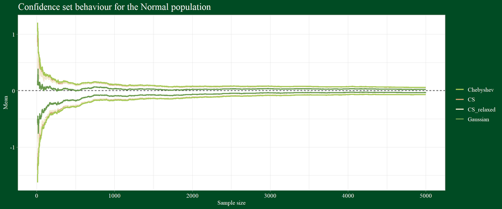

Plot of the different confidence intervals for the mean of the Gaussian distribution

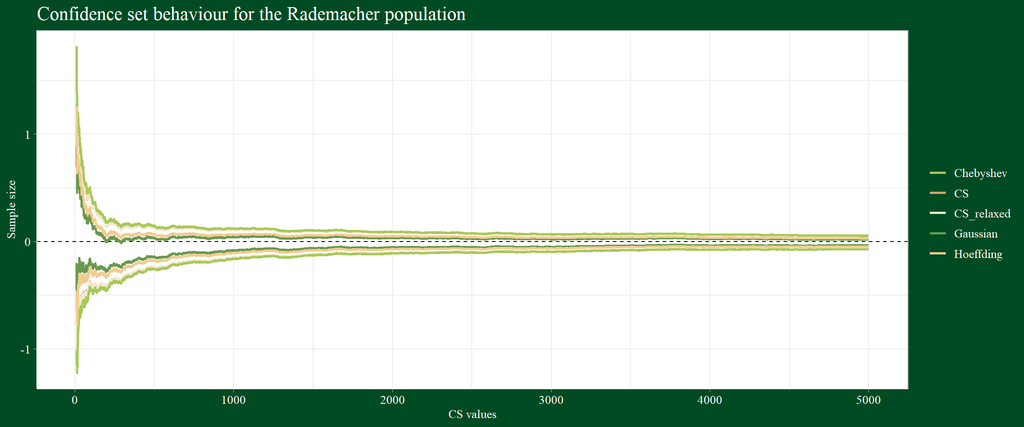

Plot of the different confidence intervals for the mean of the Rademacher distribution

For both populations, and this particular outcome, we can see that the running length of all the types of CIs we took into consideration decreases, and seems to be more or less stabilized after a certain value of the sample size. Note this is not necessarily a consistent behavior since the plot above is made by only one run of the simulation, we will see if our hypothesis is confirmed by the analysis of the Average Running Length.

To be able to perform this kind of analysis, we now summarize the measurements we got from the simulation as explained in the section “Metrics”.

### Average Running length analysis

First of all, let us highlight that we didn’t calculate the Hoeffding bound since this distribution doesn’t have a bounded support. For the other type of confidence intervals/sequences we had to compute, here we have a plot of their average running length behavior.

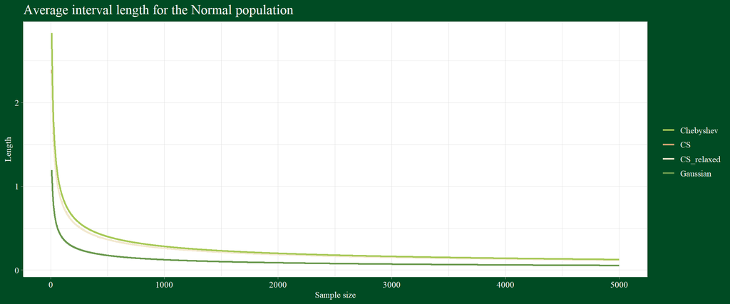

Plot of the different length of the confidence intervals fo the Normal distribution

As we can see from it, for a Standard Gaussian population, the average running length of all this intervals is similar, except for the Gaussian Interval, whose length is significantly smaller than the others’. Bigger differences between different types of intervals can be seen for smaller sample sizes: for a sample of size $10$, we can see that, on average, the running length of the relaxed version of the confidence sequence is more than the double of the one of the Gaussian interval, and all the others are more than $1/3$ bigger of this one.

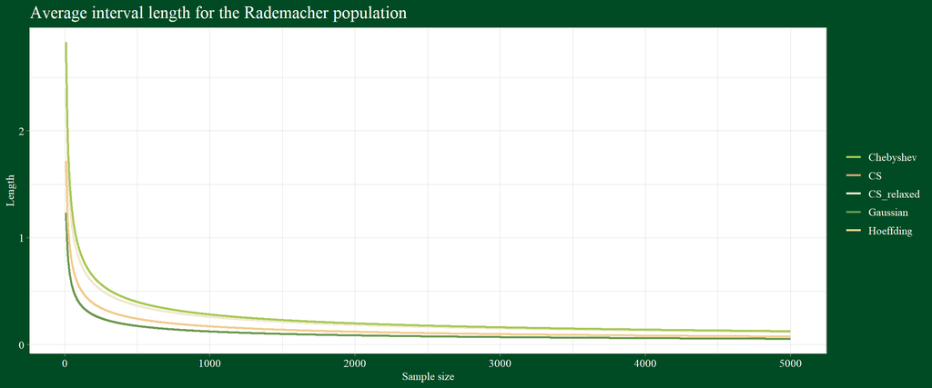

Plot of the different length of the confidence intervals fo the Rademacher distribution

For the Rademacher population the situation is a bit different, but the considerations made above are still valid. We can now also analyze the behavior of the Hoeffding interval: the average running length of this type of interval is in between the one of the Gaussian interval and all the others, whose ARL is almost the same.

Further analysis on this measures can be made w.r.t. the Cumulative Miscoverage Probability: the two quantities need to be analyzed together if we want a more comprehensive view of the situation.

### Cumulative Miscoverage Probability

For the Gaussian population, these are the values of the CMP w.r.t. the sample size:

|  | sample_size | CS | CS_relaxed | Cheb | Gauss |
| --- | --- | --- | --- | --- | --- |
| 1 | 10 | 0 | 0.028 | 0 | 0.085 |
| 91 | 100 | 0 | 0.001 | 0 | 0.055 |
| 491 | 500 | 0 | 0.000 | 0 | 0.046 |
| 991 | 1000 | 0 | 0.000 | 0 | 0.057 |
| 2491 | 2500 | 0 | 0.000 | 0 | 0.059 |
| 4991 | 5000 | 0 | 0.000 | 0 | 0.070 |

For this population, as we can see from the table above, all the types of CIs, except from the Gaussian, have Cumulative Miscoverage Probability that is significantly below the $\alpha$ required. On the other hand, the Gaussian interval doesn’t have this behaviour: for “small” sample sizes (reasonably, sample sizes below 30), that’s what we expected, but this is very unlikely for “big” sample sizes, since the Gaussian Interval is asymptotic, thus increasing the sample size should lead to a better estimate of the parameter.

|  | sample_size | CS | CS_relaxed | Hoeff | Cheb | Gauss |
| --- | --- | --- | --- | --- | --- | --- |
| 1 | 10 | 0 | 0.021 | 0.001 | 0 | 0.117 |
| 91 | 100 | 0 | 0.000 | 0.015 | 0 | 0.052 |
| 491 | 500 | 0 | 0.000 | 0.009 | 0 | 0.054 |
| 991 | 1000 | 0 | 0.000 | 0.007 | 0 | 0.056 |
| 2491 | 2500 | 0 | 0.000 | 0.004 | 0 | 0.052 |
| 4991 | 5000 | 0 | 0.000 | 0.003 | 0 | 0.044 |

Besides, for the Rademacher population we get similar results in terms of general behaviour: for all the confidence intervals/confidence sequences the CMP is significantly below the level required, except for the Gaussian CI. However this time this interval’s CMP evolution is more similar to what the expected one: it’s above $0.05$ with a sample size equal to ten, and then floats around the required level. Moreover, also the Hoeffding’s interval, that we didn’t analyze before, has a CMP consistently below $0.05$.

One more thing that we want to highlight is the CMP of $0$ reached by the Confidence Sequence and Chebishev interval for both the Gaussian and the Rademacher population.

### Conclusions

The aim of this exercise was to confront the performances of different types of confidence sets for the mean of two 1-subgaussian populations. Let us recall that, given all the ingredients needed, a set is a *good* confidence set satisfies both the characteristics of having a given confidence level and that of having a sufficiently small measure (in the case of intervals, length). “Fortunately” the metrics we computed to evaluate the CS performance measure exactly these two things. What is left to do is compare them, leveraging what we said when analyzing each one of them.

Under the considerations we just made, Hoeffding bound seems the go-to if we are dealing with a population extracted from a distribution with bounded support, but this requirement itself is obviously not satisfied by all 1-subgaussian distributions (see the standard Gaussian itself).

The confidence sequence, the Chebyshev interval and the “relaxed version” of the confidence sequence, have highly comparable performances since they have a very low CMP - always or almost always $0$ - and their lengths don’t seem to differ from the plot, except that for very small sample sizes, for which Chebyshev’s interval length is bigger than the others. To distinguish between these three intervals, another thing that can be done is look at the requests for their computation (aka, the hypothesis that the distribution of both the population and the estimated parameter have to satisfy).

For the sake of clarity, let us recall that we are conducting an analysis on 1-subgaussian populations, so this hypothesis is taken for granted, even if not needed in the case of Chebyshev interval, which of course makes the applicability of this type of interval broader, even if that’s not what we want to highlight here.

The hypothesis needed for this types of intervals are the following:

- Chebyshev’s interval is based on Chebyshev’s inequality, that requires only to have an integrable distribution with finite non-zero variance;
- the confidence sequence we computed doesn’t have any further requirements;
- its asymptotic version requires a population with a finite variance.

Given these observations, the only thing we can say is to use the confidence sequence in case of a population with a non-finite variance.

The last interval type to analyze is the Gaussian one, that has a behaviour significantly different from the others both in terms of ARL and CMP. The first thing that capture our attention is that for *small sample sizes*, every other type of interval should be preferred because of the high CMP of this interval. For *big sample sizes*, since this interval’s AVR is smaller than the ones of the other intervals and the CMP floats around the required level, we can interpret the previous analyzed intervals’ CMP as overshooting, and declare that the performances of the Gaussian interval are someway “better”. On the other hand, the ARL of all this types of interval are very small, and also the Gaussian interval requires the population to have a finite variance (it’s based on the CLT), so it could not be applicable for some distributions.

To conclude, these are only some considerations we can make on a “high-level” perspective; determine which of the confidence set is better to use in practice is application dependent, and could not be determined *a-priori*, but of course having a summary of observations on the performance and requirements of these types of intervals is a good start.

# Exercise 2

## Introduction

The second proposed exercise asks us to *model in detail a sequential and realistic experiment* over a study that wants to investigate correlations between environmental sound levels and mood. We are asked to describe all the phases of the experiment from the data gathering process, the tools used, the population parameter of interest, interventions we plan to make and the statistics used to get results over the obtained data.

## Specialization of the question

Given that the research question has been voluntarily loosely specified in the exercise text we want to *decide and set a specialization for the study* we want to address. In particular we decided to focus on the **effects environmental noise can have over the concentration level of students during study sessions**.

We made this choice based on the fact that both the population and the target of the study will be easily accessible to us since we can use ourselves as subjects and the data gathering activity would be easily superimposable with our daily routines during the winter exam session. Moreover restricting from the general mood to a single but meaningful aspect can greatly help the data gathering process, given that as we will describe later we decided to use self-reports to get data from subjects and something *more objectively measurable* than feelings or emotions can help to reduce the subjectivity of the measurements taken by the subjects.

## Population

We described the subjects of our study simply as “students”, this generic specification makes us able to *easily adapt the size of the population* over which gather the data for the study we intend to perform. For a small-scale study, the **three members of our team** would be sufficient while if we wanted to increase the scale of the analysis we may take into exam all the students of the course.

Those two proposals however *bias our results* towards the behaviors of master degree students, in particular those of Data Science. While there will reasonably be a similarity with behaviors of master students of other scientific disciplines the results may differ from what we could get from bachelor’s degree students, students of humanistic subjects or even younger students frequenting high or middle school.

We can generalize the study even more by extending the population to many different kinds of students, this could help us to generalize the results we will obtain and even understand how age or studied subject may relate to the focus levels, but that is beyond the scope of the study and requires an effort far greater than what we can realistically do.

## Concentration levels

We need a way to measure or at least get a rough idea of the concentration levels of every person in the experiment over the time period we intend to analyze. We asked *ChatGPT* to provide a list of ways to *measure the level of focus of someone studying*, we briefly report here those that seemed the more meaningful:

- **Task Completion:** the subjects are asked to solve assignments as problem-solving tasks, standardized cognitive tests or reading comprehension activities.
- **Self-Report:** the subjects use a subjective numeric scale to rate their concentration periodically. Advantages of this approach are the ease of understanding for the user and the fact that it allows the user to compare the current focus level with the previous ones.
- **Biometric Data:** understand the focus on an individual by measuring physiological indicators such as heartbeat rates, electroencephalogram or the traking of eye movements.
- **Behavioral Observations:** researchers observe and document behaviors of the subjects during the study sessions and then convert this observational data into quantitative measures.

Since we are asked to provide a *realistic experiment* we are forced to remove the last two proposals, they would require specialized equipment or a excessive amount of time to observe subjects and knowledge to understand their behavior.

Given that we want to understand the measure of focus of the individual solely about the studying activity we believe it’s *important to avoid the eventuality that the assessment process itself may be distracting the subject*; we need it to be short and immediate to complete, we therefore decided to go for using a **self-reported scale of concentration**.

For the **granularity of the data** we want a scale that has multiple choices to increase the precision of the measurements and to give the user a better way to compare previous and current perceived focus levels, but an excessive granularity may overwhelm the user and increase the time of the decision making process, with the risk of falsifying the data. We believe **a scale that spans from 1 to 10** to be the best compromise, also because the same scale range is often used in different surveys and subjects may be more accustomed to use this scale.

Another factor to decide is the **frequency of the measures**, how often we ask the subjects for a new measurement of their focus level. We require the requests to not be deteriorating of the focus level they want to measure by being too frequent but also to be frequent enough in such a way that the single value given by the measurement is a good estimate of the overall focus level for the span of time it considers. Taking into account both those considerations we believe time spans of about **30 minutes / 1 hour** to be a good compromises.

## Enviromental sound levels

The other type of measurement we need to realize is about the *level of noise experienced by the subjects*. We could insert this factor in the measurement report the subject needs to compile, but since unlike the mood *this measure is objective* it can also be obtained without human intervention by using audio recording apps on the subjects phones, to record the ambient noise levels during study hours and to be later be analyzed to extract any kind of meaningful information we may want.

This approach is particularly welcomed in our study since it *requires no further interruptions by the subject*.

Furthermore we could consider to classify the noise experienced by the subjects into two classes by asking to the user the following question during the measurements: *“Do you believe the noise you experienced in this time span to have improved, worsened or not influenced your focus?”*

In this way we would be able to distinguish between those sounds that subjects may find distracting as other people talking, traffic or construction sites and sounds that some people may instead even find to help focus, as white noise or instrumental music. Moreover the answer to this question can help us understand the noise tolerance level of the target for that specific time span.

## What is sound?

What kind of data do we want to extract from the audio files? To know what would be useful to use we first need to **understand what is sound and how digital sound and human hearing works**. Sound is a vibration that propagates trough air and is perceived by humans when the waves hit their ears and the vibration of bones inside the ear is converted into nerve signal that brain can elaborate. Microphones work in a very similar way, the sound waves make a diaphragm vibrate and the oscillations are translated into an electrical current.

Sound (as any other type of waves) can be described by two components: **frequency** and **amplitude**. Frequency represents how fast the wave oscillates, it is measured in *Hertz* (Hz) and humans can usually perceive sounds in the range from 20 to 20.000 Hz, with the upper limit diminishing with the age. Amplitude represents how “strong” the oscillation is, it is measured in *Bels* (but Decibels dB are more used) with a logarithmic scale, this because the way humans interpret the increase of amplitude is better represented by a logarithmic scale and therefore dB are more easily interpretable. The lowest humans can usually hear is 0 dB but those are extremely faint sounds, even only a whisper is around 30 dB, while there is no real upper limit, but sounds above 120 dB can be dangerous, cause pain and even inflict permanent damage to the hearing system.

[figure not shown]

Decibel chart of sounds humans can hear.  
Source: https://www.mdhearingaid.com/blog/decibel-chart/

It is important to note that *what we hear is usually a sum of different waves*, each with its own frequency and amplitude. In the digital world this decomposition is made with the use of **Fourier Transforms**.

The first thing we can do to understand what our audio file contains is to use them to create *spectrograms*, visual representations of frequencies spectrum of an audio signal where usually the x-axis represents time, the y-axis frequency and the color of the heatmap represents the amplitude of the frequencies at a given point in time. To create this kind of data from the audio file we will use *Python* and the library *Librosa*.

We show below an example on a “toy” audio file of 15 seconds created using a phone microphone. The audio contains a person humming for 5 seconds, background noise for other 5 seconds and a person whistling for the last 5 seconds.

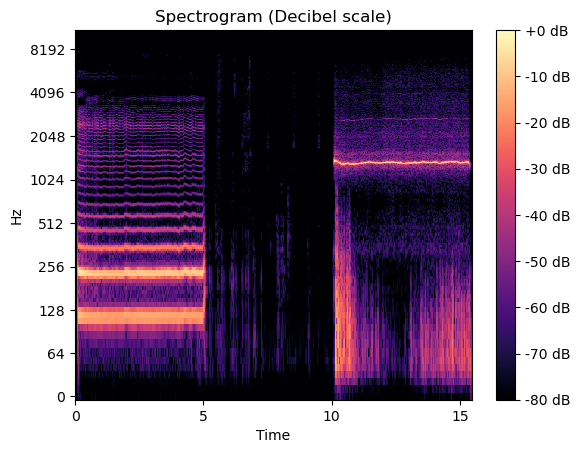

Spectrogram of the example audio file.

We can observe very distinct behaviors between the three parts of the test: the humming produced various wavelengths of noticeable strength, the second part shows some background noise in the lower frequencies and the whistling produced a very strong line in a very small frequency band.

We can also observe that the scale of the decibels has 0 dB as the highest value and every other value as negative. This is because differently from analog sound *in digital sound 0 dB is the reference point*, usually meaning the limit of the tool used and therefore every other measure will be below it.

While the measure of sound as a physical phenomenon is totally objective it’s important to point out that the *percieved loudness* of a sound is instead a subjective measure and moreover does not depend solely on the amplitude of the wave but also in part on the frequency. In fact it can be shown with *Equal-loudness contours plots* that humans have a better sound perception for sounds in the middle of their hearing range with peaks around 2kHz-4kHz, probably due to evolutionary reasons, as sounds of animals and other humans usually fall in that range.

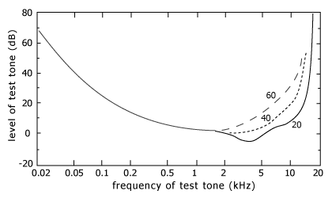

Equal-loudness contour.  
Source: https://www.fabfilter.com/learn/science-of-sound/perception-of-frequency-and-loudness

There is no exact formula that can capture the perceived loudness of a sound, we are therefore forced to use subjective measures. The first thing we can extract can be a measure of the average loudness of the audio. A measure often used with this objective is **Root Mean Square Energy**, where Root Mean Square has the same mathematical meaning we already know:

$RMS = \sqrt{\frac{1}{N} \sum_{i = 1}^N|x_i^2|}$

$SP = \frac{\sum_{i=1}^Nf_i*x_i}{\sum_{i=1}^Nx_i}$

And as before to get a summary for the whole audio file we take the mean of the spectral centroids of every discrete time unit in the audio file.

## Focus report

About the tools used to gather those reports we will need *two components* to create an efficient pipeline, a system to notify the user when it’s time to fill out a new report and a way to make the user easily and quickly compile the report and move data from the subject to us.

As we have said before it is imperative for us to avoid as much as possible the disruption of the workflow of the subject, we therefore need the data gathering process to not be intrusive.

A very *fast way make the subjects fill out reports* is via the use of **Google Forms**, a web application part of the Google Workspace Suite that allow us to create online forms accessible by simply sharing a link. In just a few seconds and only 5 clicks the subject will be able to send the report containing its responses, its email address to make us able to identify the subject and the delivery timestamp to understand the time span the report is about. The reports *results are automatically exported* into a **Google Sheet** table containing all the responses from all the subjects.

Google forms are also *extremely versatile*, permitting the subjects to access and compile them via browser, therefore they can be accessed via Personal Computer or Smartphone without the need to download any specific app. The submission of a new report is also very easy for the subject as it’s just needed to use the same link or click on “submit another response” over the previously completed form.

[figure not shown]

The form we created. It can be accessed from the following link: https://forms.gle/ariWQ29wpAuSJpRd6

For the user notification system the *best approach to use depends on the user* itself, we believe the user should select its preferred way of being notified to write the report. The two main proposals we make are:

- A simple visual notification system, ideal when the subject is working on a computer and is constantly looking at the screen as its very discrete and not interrupting of the user workflow. As app we found to implement this is **Custom Notifications 10** for Windows systems (https://apps.microsoft.com/detail/9NBLGGH529DX).

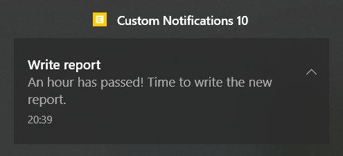

The notification that appears on the user screen, together with the usual notification sound

- A more intrusive approach considers the use of ringtones, for when the user is studying on physical books or handwritten notes; the ringtone is more distracting, but in this case a simple notification would be not enough as it could be mistaken for something else and lost. An app we propose to easily create multiple alarms separated by a certain time interval is **Repeat Alarm** for Android phones (https://play.google.com/store/apps/details?id=com.kittoboy.repeatalarm).

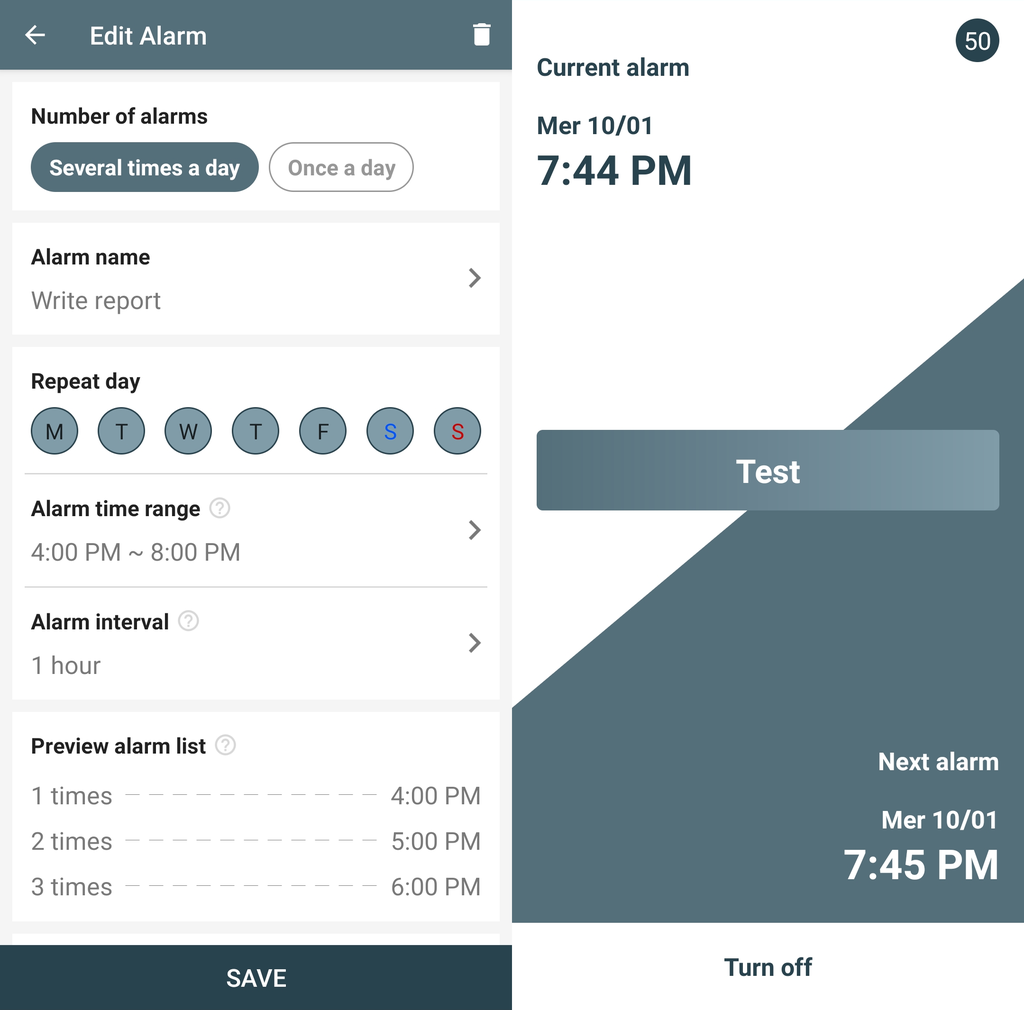

On the left the ringstone setup settings and on the right the ringtone screen

## Noise record and feature extraction

We have decided to take as approach to measure the noise experienced by the subjects during a certain time span the recording of the nearby environment sounds. The subject will only be asked to record the noise of the working environment and analysis over it be performed on a later date.

There are a multitude of phone apps that permit the record of audio from the microphone but the one we suggest is *Audio Recorder* (https://play.google.com/store/apps/details?id=com.dimowner.audiorecorder), given its lack of ads and the presence of personalization features to change the file format, the sample rate, the bitrate and other settings.

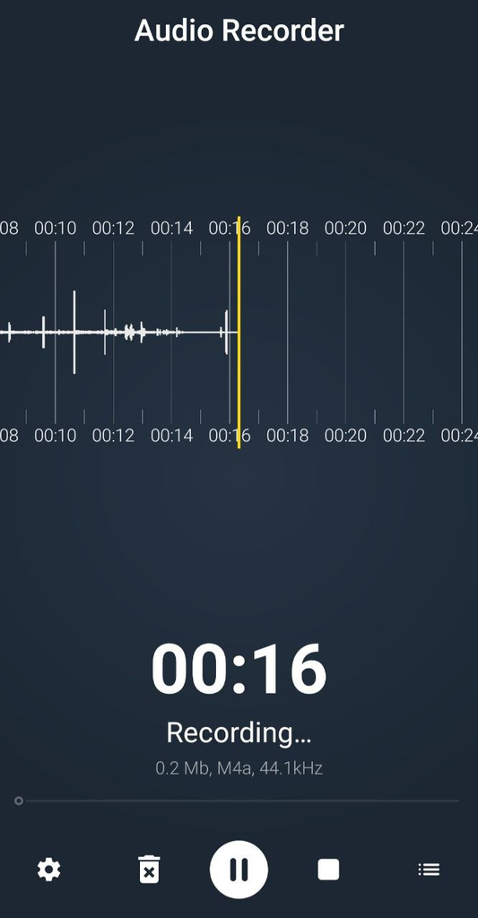

Screenshot of the Audio Recorder app

If the user is using devices as headphones to cover external noises the recording of only the external audio may not be enough. We can argue that if the user is deliberately exposing itself to sounds during studies those will be positive to its focus, but in the case we would want to study those sounds we will need to record also internal phone audio. While we haven’t been able to find an audio-recording app capable of record both internal and external audio the *default Android screen recorder* has this capability, at the expense recording also the device screen and therefore forcing us to separate the audio from the video in a second moment.

For the features extraction part as said before we will use *Python* and the library *Librosa*. We wrote a simple script capable of extracting the requested features. This file will be submitted together with the rest of the homework. As examples to show the output of the script we now show the Rooted Mean Square Energy and the Spectral Centroid for the previous test audio file and for another file recorded in a quiet room with only the sound of a laptop fan:

*Test 1 RMS: 15637.07*  
*Test 1 SP: 1766.15*

*Test 2 RMS: 78.79*  
*Test 2 SP: 2759.68*

## IID Sampling problem

The setup we have built has some problems about the sampling independence: since we are taking measurements over study sessions of certain individuals hour by hour there will be *temporal dependences* over the measurements, the current day *general mood* of the analyzed person works as a *hidden variable* that can interfere with the focus measurements of the day.

The temporal dependence causes also a dependence in the measured noises as a subject tends to stay in the same place during a study session and the kind of environment heavily influences the noise levels that will be observed: a library or a private room will be quieter than a public study place or somewhere near a busy road.

It has also to be taken into account that extended study sessions may have negative effect on the focus levels of the subject, we may observe a diminishing of the concentration simply out of weariness of the subject.

We also have dependence given by the study subjects themselves: an individual tends to have preferences over where to study and as discussed in the previously this greatly influences the ambient noise levels that will be experienced and measured.

Another kind of dependence given by the subjects are the personal noise tolerance levels, some people may not find certain sounds as distracting as others do and even this perception can be influenced by the individual current mood or fatigue.

How can we remove or at least reduce the dependence between the measurements?

The easier way to grant a good representation and diversity in the data is to increase the number of people who participate to the experiment and to diversify them by preferences and habits, but this approach seems not to be easily applicable in our scenario given the limited amount of test subjects we may be forced to work with.

To remove the temporal dependence of measurements carried out by the same subject in the same study session we can take a single measurement for the whole day or summarize all the measurements taken in a day into a single result. This reduces the dependence we experience between consecutive measurements, but also greatly reduces the amount of data we can work on and does not take into account that the general mood and conditions of the individual, that as we have said before can interfere with the measurements, can influence or be influenced by those of adjacent days.

## Interventions

We might also want to plan some kind of interventions over the experiment setup we built:

- **Noise-Cancelling Headphones**: headphones with noise-cancelling capability can help reduce the perceived external ambient noise and therefore boost students concentration. Noise cancelling can be implemented in a passive way by physically blocking the sound from entering the ear and in an active way by listening to the outside noise and cancelling it out with phase-inverted sound waves, however the kind of cancellation has no interest for us.
- **“Positive” Environmental Noise**: substituting environmental noise with something that could be beneficial to the focus of the user. Examples of this kind of sounds are natural sounds like rain, running water, birds or instrumental music as classical music or in general ambient music characterized by a slow tempo and minimal dynamic changes.

## A/B Test and Confidence Sequences

As the Background section in the homework text mentioned, **A/B tests** are randomized controlled and sequential experiments used for hypothesis testing where *the testing environment is always the same except for a single variation that might effect the target value*, with the purpose of measuring how this single isolated variation can influence the target value.

This type of testing is often used to enhance engagement, clicks and in general the user experience for website, given that for the case of webpages is very easy to create simple variations of their contents and “distribute” those variations among users, even without them knowing. One example of use of this technique might be to decide which location of the ads in a certain webpage yields the better click rate and therefore the highest earnings for the website.

Our experiment might use the same principles to test the hypothesis that environmental sound levels affect focus levels. Our study like those carried out for A/B testing is inherently sequential and we can occur in the same problems described in the homework text: it’s impossible to know a priori if a certain sample size will be enough. Confidence Sequences can therefore greatly help us in this scenario, permitting us to continuously monitor the experiment and insert new data when they become available.

However there are also a *few differences* between what we are planning to do and the heavily controlled and uniform scenario of a webpage: we haven’t as much control over the scenes presented to the user as a a webpage scenario can give, meaning also that there could be variables that might influence the target value and that we might haven’t take into account. This may render our observations imprecise, but as said before we can try to compensate those factors with a greater sample size for the study and is in some part unavoidable, given that to create a more controlled environment we would need an amount of effort and resources unfeasible for a realistic experiment.